# Sydney’s Cliffs

Where one side of the street is a different Sydney

## Finding

**The descriptive result.** Young Street is the sharpest advantage edge our scan found across Greater Sydney’s 11,237 analysed areas. It runs 843 m; the SA1s on one side sit at the 80th percentile of SEIFA advantage, the other side at the 0.4th. Median household income (not equivalised) is $2,512 against $435 a week. By tenure (ABS Census 2021, G37), 73.6% of stated-tenure dwellings on one side are social housing against 9.1% on the other, so the edge marks where predominantly social housing meets private housing.

**The scientific result.** Tested against simulated Sydneys with the same overall clustering, even this sharpest edge is **not statistically exceptional** (max-statistic p = 0.34; sensitivity stability 39%). At SA1 scale, Sydney’s advantage mostly changes as hills, not cliffs — and we report that openly rather than tuning the test until something passes.

## Data

| Source | Use | Licence |
| --- | --- | --- |
| ABS SEIFA 2021 and 2016, SA1 (IRSAD) | Headline advantage score | CC BY 4.0 |
| ABS 2021 Census GCP DataPack, SA1 (G01, G02) | Population, income, rent, age | CC BY 4.0 |
| ABS ASGS Edition 3 SA1 and Mesh Block boundaries | Areas, land use, change flags | CC BY 4.0 |
| OpenStreetMap via Overpass | Name of the road or rail line along each cliff | ODbL |
| Microburbs API (City of Sydney only) | Second-source check where available | Hackathon key, output not republished |

Census figures describe **areas in 2021**, not individuals. ABS applies small random adjustments to cells to protect confidentiality, which is one reason for the population floor below.

Data QA: 12,175 SA1s in scope; missing IRSAD 2021 3.8%, household income 2.0%, rent 2.7%; IRSAD mean 1,046 (the parser refuses the sheet if this drifts from 1000). Suppressed ABS medians (published as 0) are treated as missing, never as $0.

## Method

1. **Universe.** 12,175 Greater Sydney SA1s; we keep those with at least 150 residents and at least 20% residential land (mesh block categories), leaving 11,237 areas.
2. **Neighbours.** Two SA1s are neighbours when their boundaries share at least 50 m of line (rook contiguity measured on the ground): 25,833 pairs, 31 islands.
3. **Clusters (LISA).** Local Moran’s I with 9,999 conditional permutations on neighbourhoods up to order 2, Benjamini-Hochberg FDR at q = 0.05. Global Moran’s I = 0.836.
4. **Cliff borders.** Each border splits its neighbourhood into two sides. A border is a cliff border when the gap between the side means is in the top 5% of all borders **and** the high side contains a significant High-High SA1 while the low side contains a significant Low-Low SA1. A lone outlier cannot pass, because its side is averaged with its ordinary neighbours.
5. **Cliff lines.** Cliff borders within 150 m of each other merge into one line, so one noisy border cannot split a cliff; lines shorter than 400 m are dropped. Score = median side gap (in standard deviations) x log(length), so scores are comparable between the real map and the surrogate maps.

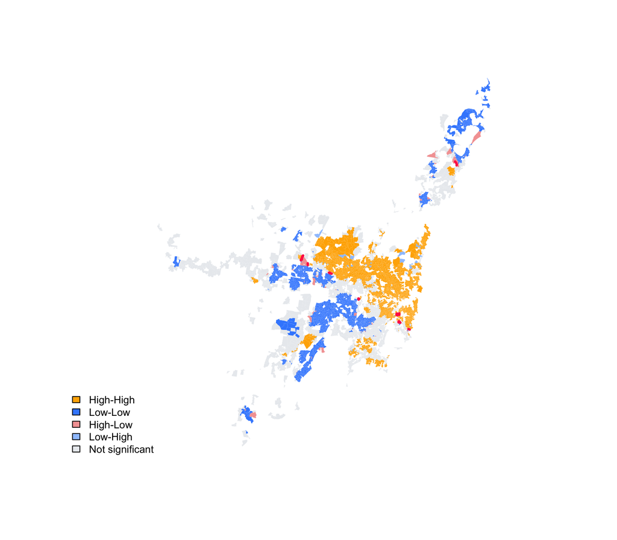

LISA clusters (FDR-adjusted) with cliff lines in red.

## Held-out checks

A cliff is only reported if it survives three tests it was not tuned on:

- **Spatial null.** Surrogate maps from a SAR process calibrated to the same global Moran’s I; we rerun the whole search on each and compare every real cliff with the *best* cliff in each surrogate (max-statistic, controls family-wise error).
- **Time.** The same search on SEIFA 2016, restricted to SA1s whose boundary did not change between ASGS 2016 and 2021. Scores are standardised within year, as ABS advises against comparing raw SEIFA scores across releases.
- **Sensitivity.** Population floor x minimum border x FDR level (18 runs). Stability = share of runs in which the cliff stays in the top 20.

| line_id | border_name | border_kind | hi_area | lo_area | length_m | score | p_null | in_2016 | stability | passes_all |
| --- | --- | --- | --- | --- | --- | --- | --- | --- | --- | --- |
| 1 | Young Street | road | Redfern | Redfern | 842.905 | 23.001 | 0.34 | FALSE | 0.389 | FALSE |
| 2 | Botany Road | road | Redfern | Waterloo | 1,271.665 | 18.899 | 0.76 | FALSE | 0.500 | FALSE |
| 3 | Fitzgerald Avenue | road | Maroubra - South | Maroubra - South | 527.852 | 12.733 | 1.00 | TRUE | 0.278 | FALSE |
| 4 | Glengarrie Road | road | Marsden Park - Shanes Park | Marsden Park - Shanes Park | 2,697.395 | 12.217 | 1.00 | FALSE | 1.000 | FALSE |
| 5 | Asquith Avenue | road | Rosebery - Beaconsfield | Rosebery - Beaconsfield | 532.922 | 11.140 | 1.00 | FALSE | 0.833 | FALSE |
| 6 | Richmond Road | road | Schofields (West) - Colebee | Marsden Park - Shanes Park | 696.268 | 10.779 | 1.00 | FALSE | 0.778 | FALSE |
| 7 | Carnarvon Street | road | Silverwater - Newington | Silverwater - Newington | 693.843 | 9.427 | 1.00 | FALSE | 0.222 | FALSE |
| 8 | Tumbi Road | road | Wamberal - Forresters Beach | Wamberal - Forresters Beach | 1,690.755 | 9.392 | 1.00 | TRUE | 0.500 | FALSE |
| 9 | Marton Crescent | road | Lalor Park - Kings Langley | Lalor Park - Kings Langley | 1,360.828 | 8.730 | 1.00 | FALSE | 0.500 | FALSE |
| 10 | Gardeners Road | road | Rosebery - Beaconsfield | Eastlakes | 689.995 | 8.264 | 1.00 | FALSE | 0.333 | FALSE |

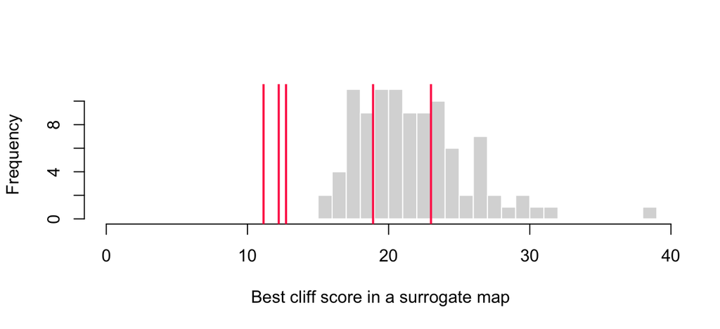

Best cliff score in each surrogate map (grey) vs real cliffs (red).

**Interpretation.** 33 of the 99 surrogate maps produced a best edge scoring at least as high as the top real edge (p = 0.34). Because each surrogate is re-searched with exactly the same scan, this is the honest benchmark: Sydney-smooth maps routinely contain an edge this sharp somewhere. The descriptive finding stands; the claim of statistical exceptionality does not, and we do not make it.

**Second source (Microburbs 2026 estimates).** Microburbs’ income map (median weekly household income per microburb, one ABS mesh block each) puts the higher side of Young Street at $2,406/wk (median of 15 microburbs) and the other side at $1,528/wk (6 microburbs) — Microburbs 2026 estimates. The result is **consistent with** our ABS figures: the direction and a substantial divide agree, while the magnitude is smaller, as expected from a different source and year (ABS 2021 Census medians vs Microburbs 2026 model estimates, which smooth extremes). Microburbs estimates may draw on the same ABS Census inputs, so this is a consistency check rather than fully independent confirmation. As context, in neighbouring Waterloo the same endpoint ranges from $1,213/wk on Cope Street to $2,389/wk on Bourke Street (Microburbs 2026 estimates).

## Social housing at the edge (ABS G37)

Share of occupied private dwellings (tenure stated) rented from a state/territory housing authority or community housing provider, among the SA1s touching each line:

| line | border | high side | low side | social rent, high side % | social rent, low side % |
| --- | --- | --- | --- | --- | --- |
| 1 | Young Street | Redfern | Redfern | 9.1 | 73.6 |
| 2 | Botany Road | Redfern | Waterloo | 22.1 | 69.4 |
| 3 | Fitzgerald Avenue | Maroubra - South | Maroubra - South | 0.0 | 61.4 |
| 4 | Glengarrie Road | Marsden Park - Shanes Park | Marsden Park - Shanes Park | 0.0 | 0.0 |
| 5 | Asquith Avenue | Rosebery - Beaconsfield | Rosebery - Beaconsfield | 0.0 | 0.0 |
| 6 | Richmond Road | Schofields (West) - Colebee | Marsden Park - Shanes Park | 0.0 | 0.0 |
| 7 | Carnarvon Street | Silverwater - Newington | Silverwater - Newington | 0.0 | 0.0 |
| 8 | Tumbi Road | Wamberal - Forresters Beach | Wamberal - Forresters Beach | 0.0 | 0.0 |
| 9 | Marton Crescent | Lalor Park - Kings Langley | Lalor Park - Kings Langley | 0.0 | 0.0 |
| 10 | Gardeners Road | Rosebery - Beaconsfield | Eastlakes | 0.0 | 0.0 |

“Predominantly social housing” is said only of a side above 50%. One SA1 can touch a line on both sides across different borders and is then counted in both side aggregates.

## Advanced analysis

Step-vs-slope and 2016-change for the top lines (95% bootstrap CIs; – = not estimable, usually too few unchanged-boundary SA1s). A ‘degenerate’ width means the fitted transition collapsed below the ~170 m SA1 resolution: it is an estimator boundary, not a physical width.

| line | border | n | delta_bic | width_m | jump_500 | stable | gap_change |
| --- | --- | --- | --- | --- | --- | --- | --- |
| 1 | Young Street | 199 | -1.0 [-6.9, 10.2] | degenerate | 3.80 [-0.23, 6.98] | TRUE | – |
| 2 | Botany Road | 211 | 22.5 [-3.8, 88.0] | 6 [0, 218] | 1.84 [-0.61, 4.78] | FALSE | – |
| 3 | Fitzgerald Avenue | 83 | -0.8 [-5.9, 5.0] | 10 [0, 54] | 2.30 [-1.57, 12.01] | TRUE | – |
| 4 | Glengarrie Road | 29 | – | NA | – | NA | – |
| 5 | Asquith Avenue | 110 | 0.9 [-5.9, 9.8] | 340 [5, 727] | -0.87 [-5.94, 14.56] | NA | – |
| 6 | Richmond Road | 30 | -6.6 [-6.8, 7.6] | 5592 [135, 34702] | – | NA | – |
| 7 | Carnarvon Street | 57 | 19.2 [8.2, 40.9] | 349 [0, 752] | – | NA | – |
| 8 | Tumbi Road | 27 | -3.2 [-6.8, 0.5] | degenerate | – | NA | – |
| 9 | Marton Crescent | 73 | 11.3 [-1.9, 33.8] | 49 [3, 1563] | -0.15 [-3.39, 3.91] | FALSE | 0.15 [-0.11, 0.52] |
| 10 | Gardeners Road | 108 | 9.4 [2.5, 18.8] | 2 [0, 103] | – | NA | – |

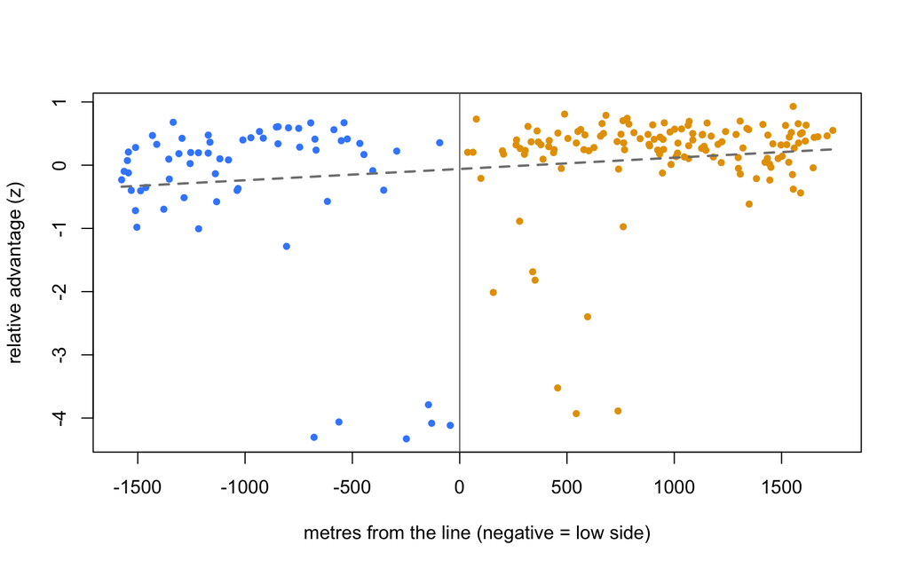

Descriptive transect of the chosen edge: relative advantage (z) against signed distance from the line, with a straight-line fit. No discontinuity is claimed: the step-vs-slope test was inconclusive here.

**Chosen line (Young Street):** the highest-scoring edge; no line passed all held-out checks, so every claim about it is descriptive. Jump at the line 3.80 (95% CI -0.23 to 6.98) SD (the CI includes 0); step-vs-slope delta BIC -1.0 (95% CI -6.9 to 10.2) — inconclusive between step and slope. The fitted transition width is degenerate (below the ~170 m SA1 resolution) and is not quoted as a physical width. The 2016 comparison is not available here: too few SA1s beside the line kept the same boundary across ASGS editions.

## What worked

- 10 cliff lines met the definition; 0 of the top 10 pass all three checks.
- The method recovers a planted cliff and ignores a planted outlier and a smooth gradient in the automated test suite (`tests/`).

## What did not work

- 10 top-ranked lines failed at least one check and are not used in the post.
- Every top line follows a road, so no line had to be set aside as a mere water or park boundary.
- SA1s vary in size; very small inner-city SA1s make lines short, which the 400 m minimum length penalises.

## Limits

- Household income is **not equivalised** for household size or composition.
- SA1 resolution limits spatial precision, and ABS designs SA1s around relatively homogeneous areas — so where an edge falls partly reflects that geographic design.
- **Winner’s-curse inflation**: the top-ranked gap is selected as the maximum of thousands of candidates, so its size is biased upward; the max-statistic null is our guard, and it did not pass.
- The bootstrap resamples SA1s independently, without spatial blocks, so confidence intervals are approximate and likely **too narrow**.
- The SAR surrogate null assumes broadly uniform clustering across Sydney; real clustering varies spatially.
- The 2016 comparison is **not comparable** for the chosen line: SA1 boundaries were redrawn, and only about 28% of SA1s within 1 km kept their boundary.
- The transition cannot be resolved below about one SA1 — roughly 170 m here; the fitted “width” is degenerate and is not quoted as a physical width.
- **No line passed the full primary test at final settings**; every published claim about the chosen edge is descriptive.
- Area-level data: differences between neighbourhoods, never statements about individuals (ecological fallacy); a cliff shows *where* things change, not *why*.
- 2021 Census; areas may have changed since.